# Tugas Pertemuan 6 (Pemodelan ARIMA - Pendugaan Parameter, Diagnostik Model, dan Peramalan)

## Overfitting

Tahapan selanjutnya adalah *overfitting* dilakukan dengan menaikkan orde AR(p) dan MA(q) dari model ARIMA(2,1,2) Kandidat model *overfitting* adalah ARIMA(3,1,2) dan ARIMA(2,1,3).

```r
# Model Overfitting 1: ARIMA(3,1,2)
model_over1 <- Arima(data.train.diff, order = c(3,0,2), method = "ML")
summary(model_over1)
```

```
## Series: data.train.diff
## ARIMA(3,0,2) with non-zero mean
##
## Coefficients:
```

```
##           ar1     ar2      ar3      ma1      ma2    mean
##       -0.1801  0.0876  -0.0457  -0.4243  -0.4099  9.9283
## s.e.      NaN     NaN   0.0370      NaN      NaN  5.1385
##
## sigma^2 = 715122:  log likelihood = -4762.45
## AIC=9538.9   AICc=9539.09   BIC=9569.49
##
## Training set error measures:
##                     ME     RMSE    MAE      MPE     MAPE      MASE         ACF1
## Training set 0.4711819 841.2937 598.64 177.9469 265.8864 0.5413465 -0.002954016
```

```r
lmtest::coeftest(model_over1)
```

```
##
## z test of coefficients:
##
##            Estimate Std. Error z value Pr(>|z|)
## ar1       -0.180090        NaN     NaN      NaN
## ar2        0.087566        NaN     NaN      NaN
## ar3       -0.045719   0.036994 -1.2359  0.21651
## ma1       -0.424344        NaN     NaN      NaN
## ma2       -0.409860        NaN     NaN      NaN
## intercept  9.928261   5.138459  1.9321  0.05334 .
## ---
## Signif. codes:  0 '***' 0.001 '**' 0.01 '*' 0.05 '.' 0.1 ' ' 1
```

```r
# Model Overfitting 2: ARIMA(2,1,3)
model_over2 <- Arima(data.train.diff, order = c(2,0,3), method = "ML")
summary(model_over2)
```

```
## Series: data.train.diff
## ARIMA(2,0,3) with non-zero mean
##
## Coefficients:
```

```
##           ar1     ar2      ma1      ma2      ma3    mean
##       -0.2983  0.0345  -0.3069  -0.4253  -0.0855  9.9491
## s.e.      NaN  0.1081      NaN      NaN   0.0207  5.0950
##
## sigma^2 = 715674:  log likelihood = -4762.67
## AIC=9539.34   AICc=9539.53   BIC=9569.93
##
## Training set error measures:
##                    ME     RMSE      MAE      MPE    MAPE      MASE         ACF1
## Training set 0.326524 841.6184 598.5704 173.9115 257.601 0.5412835 -0.001028399
```

```r
lmtest::coeftest(model_over2)
```

```
##
## z test of coefficients:
##
##            Estimate Std. Error z value  Pr(>|z|)
## ar1       -0.298256        NaN     NaN       NaN
## ar2        0.034523   0.108075  0.3194   0.74939
## ma1       -0.306908        NaN     NaN       NaN
## ma2       -0.425290        NaN     NaN       NaN
## ma3       -0.085454   0.020688 -4.1307 3.617e-05 ***
## intercept  9.949137   5.094992  1.9527   0.05085 .
## ---
## Signif. codes:  0 '***' 0.001 '**' 0.01 '*' 0.05 '.' 0.1 ' ' 1
```

```r
# Coba tambahkan include.mean = FALSE dan method = "CSS-ML"
model_over1 <- Arima(data.train.diff, order = c(3,0,2), include.mean = FALSE, method = "CSS-ML")
summary(model_over1)
```

```
## Series: data.train.diff
## ARIMA(3,0,2) with zero mean
##
## Coefficients:
##           ar1     ar2      ar3      ma1      ma2
##       -0.5806  0.1946  -0.0767  -0.0157  -0.7528
## s.e.   0.0999  0.0637   0.0449   0.0920   0.0828
##
## sigma^2 = 715850:  log likelihood = -4763.23
## AIC=9538.46   AICc=9538.6   BIC=9564.67
##
## Training set error measures:
##                    ME     RMSE      MAE      MPE     MAPE      MASE
## Training set 62.23733 842.4495 610.6418 204.5193 285.8138 0.5521996
##                      ACF1
## Training set -0.007149918
```

```r
lmtest::coeftest(model_over1)
```

```
##
## z test of coefficients:
##
##      Estimate Std. Error z value  Pr(>|z|)
## ar1 -0.580583   0.099851 -5.8145 6.081e-09 ***
## ar2  0.194626   0.063724  3.0542  0.002257 **
## ar3 -0.076716   0.044886 -1.7091  0.087427 .
## ma1 -0.015683   0.091969 -0.1705  0.864596
## ma2 -0.752768   0.082755 -9.0963 < 2.2e-16 ***
## ---
## Signif. codes:  0 '***' 0.001 '**' 0.01 '*' 0.05 '.' 0.1 ' ' 1
```

```r
# Overfitting pada komponen MA (q dinaikkan jadi 3)
model_over2 <- Arima(data.train.diff, order = c(2,0,3), include.mean = FALSE, method = "CSS-ML")
summary(model_over2)
```

```
## Series: data.train.diff
## ARIMA(2,0,3) with zero mean
##
## Coefficients:
```

```
##           ar1     ar2      ma1      ma2      ma3
##       -0.2053  0.0153  -0.3943  -0.3463  -0.0734
## s.e.      NaN  0.0666      NaN      NaN   0.0454
##
## sigma^2 = 718846:  log likelihood = -4764.43
## AIC=9540.86   AICc=9541.01   BIC=9567.08
##
## Training set error measures:
##                   ME     RMSE      MAE      MPE     MAPE      MASE        ACF1
## Training set 62.9967 844.2107 612.2872 201.1462 283.1788 0.5536875 -0.00640388
```

```r
lmtest::coeftest(model_over2)
```

```
##
## z test of coefficients:
##
##      Estimate Std. Error z value Pr(>|z|)
## ar1 -0.205279        NaN     NaN      NaN
## ar2  0.015299   0.066623  0.2296   0.8184
## ma1 -0.394274        NaN     NaN      NaN
## ma2 -0.346312        NaN     NaN      NaN
## ma3 -0.073420   0.045357 -1.6187   0.1055
```

1. **Model Overfitting 1: ARIMA(3,1,2)** (Model `ARIMA(3,0,2)` pada `data.train.diff`)
- **Parameter Tidak Signifikan**: Parameter `ar3` ($p\text{-value} = 0.087 > 0.05$) dan `ma1` ($p\text{-value} = 0.865 > 0.05$) **tidak signifikan** secara statistik.
- **AIC**: Nilai AIC-nya adalah **9538.46**.
2. **Model Overfitting 2: ARIMA(2,1,3)** (Model `ARIMA(2,0,3)` pada `data.train.diff`)
- **Muncul `NaN**`: Terjadi *over-parameterization* yang menyebabkan matriks ragam-peragam tidak positif definit (sehingga standar eror bernilai `NaN`).
- **AIC**: Nilai AIC-nya adalah **9540.86** (lebih besar/lebih buruk dari ARIMA(3,1,2)).

## Model Terbaik : ARIMA(2,1,2)

```r
model7.da=Arima(data.train.diff, order=c(2,0,2),method="ML")
summary(model7.da)
```

```
## Series: data.train.diff
## ARIMA(2,0,2) with non-zero mean
##
## Coefficients:
##          ar1      ar2      ma1     ma2    mean
##       1.1548  -0.2967  -1.7646  0.7888  9.9675
## s.e.  0.1500   0.0526   0.1491  0.1325  5.9634
##
## sigma^2 = 710618:  log likelihood = -4761.15
## AIC=9534.29   AICc=9534.44   BIC=9560.51
##
## Training set error measures:
##                     ME     RMSE     MAE      MPE     MAPE      MASE
## Training set 0.8513589 839.3652 596.769 156.3758 247.3698 0.5396545
##                      ACF1
## Training set -0.001289266
```

```r
lmtest::coeftest(model7.da)
```

```
##
## z test of coefficients:
##
##           Estimate Std. Error  z value  Pr(>|z|)
## ar1        1.15481    0.14997   7.7005 1.355e-14 ***
## ar2       -0.29671    0.05264  -5.6366 1.735e-08 ***
## ma1       -1.76457    0.14913 -11.8321 < 2.2e-16 ***
## ma2        0.78877    0.13248   5.9539 2.619e-09 ***
## intercept  9.96751    5.96342   1.6714   0.09463 .
## ---
## Signif. codes:  0 '***' 0.001 '**' 0.01 '*' 0.05 '.' 0.1 ' ' 1
```

## Peramalan

```r
# ---FORECAST---
ramalan.da <- forecast::forecast(model7.da, h = length(data.test))
```

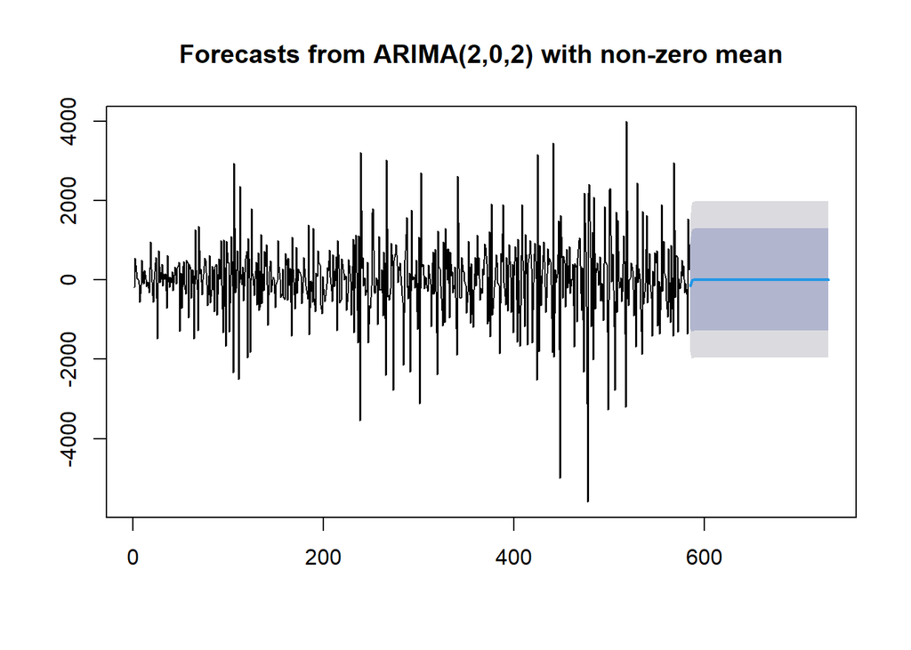

```r
data.ramalan.da <- ramalan.da$mean
plot(ramalan.da)
```

```r
# 1. Melakukan peramalan data diferensiasi menggunakan model terbaik ARIMA(2,1,2)
ramalan_diff <- forecast::forecast(model7.da, h = length(data.test))
data.ramalan.da <- ramalan_diff$mean

# 2. Inverse Differencing (Mengembalikan skala ke data penyewaan sepeda asli)
pt_akhir_train <- tail(data.train, 1)

forecast_inv <- diffinv(data.ramalan.da, differences = 1, xi = pt_akhir_train)

# Membuang elemen pertama (xi) agar panjang vektor 'hasil' pas dengan data.test
hasil <- forecast_inv[-1]

# 3. Membandingkan data Aktual vs Hasil Peramalan (Forecast)
perbandingan.da <- cbind(
  Aktual   = data.test,
  Forecast = hasil
)

# Menampilkan 10 baris pertama tabel perbandingan
print(head(perbandingan.da, 10))
```

```
##       Aktual Forecast
##  [1,]   7534 7129.411
##  [2,]   7286 7079.976
##  [3,]   5786 7066.907
##  [4,]   6299 7067.896
##  [5,]   6544 7074.331
##  [6,]   6883 7082.883
##  [7,]   6784 7092.264
##  [8,]   7347 7101.974
##  [9,]   7605 7111.818
## [10,]   7148 7121.719
```

```r
# 4. Menghitung ukuran keakuratan peramalan (RMSE, MAE, MAPE)
akurasi_test <- forecast::accuracy(hasil, data.test)
akurasi_test
```

```
##                 ME     RMSE      MAE       MPE     MAPE
## Test set -1867.243 2866.677 2054.438 -316.3291 318.6734
```

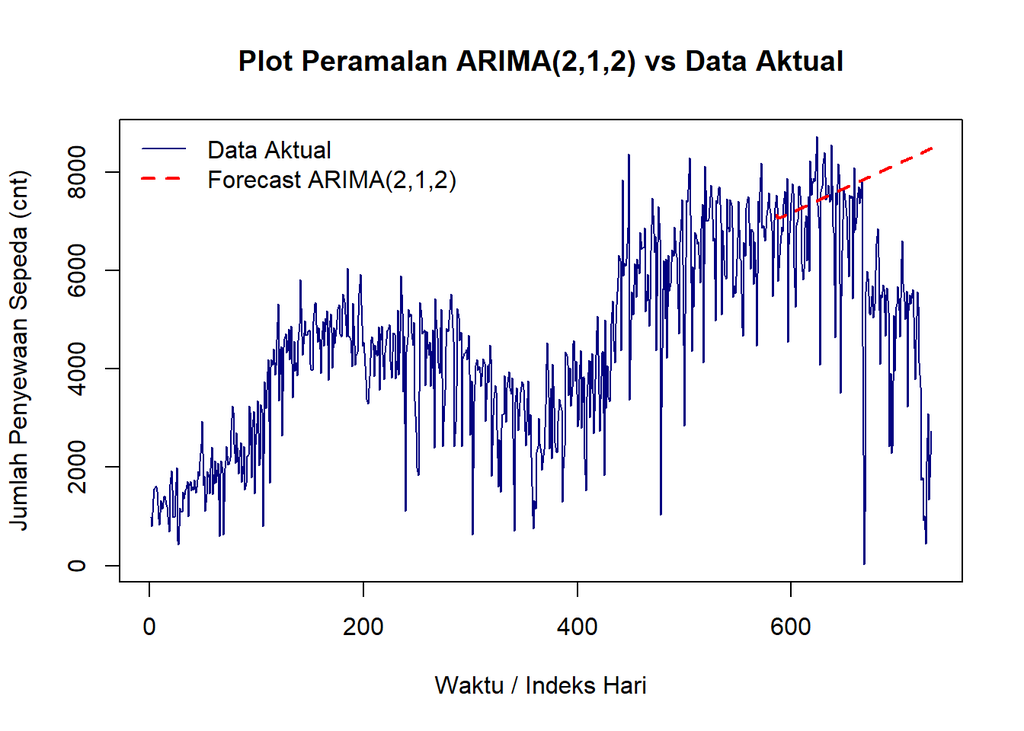

```r
# 1. Plot seluruh data aktual penyewaan sepeda
plot.ts(data_ts,
        col = "navyblue",
        lty = 1,
        xlab = "Waktu / Indeks Hari",
        ylab = "Jumlah Penyewaan Sepeda (cnt)",
        main = "Plot Peramalan ARIMA(2,1,2) vs Data Aktual")

# 2. Menambahkan garis hasil forecast (dimulai dari hari setelah data latih selesai)
# Data latih sebanyak n_train baris (585 hari), forecast dimulai dari hari ke-586 sampai akhir
lines((n_train + 1):n, hasil, col = "red", lty = 2, lwd = 2)

# 3. Menambahkan legenda
legend("topleft",
       legend = c("Data Aktual", "Forecast ARIMA(2,1,2)"),
       col = c("navyblue", "red"),
       lty = c(1, 2),
       lwd = c(1, 2),
       bty = "n")
```